# XCO2 - Aquisição de dados de XCO2

## Processamento

Verificar o banco de dados com a função `glimpse()` do pacote `dplyr`.

### Carregando os pacotes requeridos

```r
library(magrittr)
library(ggplot2)
library(dplyr)
library(tidyr)
source("../r/graficos.R")
source("../r/my_fun.R")
```

```r
xco2 <- readr::read_rds("../data/XCO2_20142020.rds")
glimpse(xco2)
```

```
## Rows: 364,529
## Columns: 11
## $ longitude                              <dbl> -74.58225, -74.58225, -74.58...
## $ longitude_bnds                         <chr> "-74.70703125:-74.4574652778...
## $ latitude                               <dbl> -30.22572489, -29.97654828, ...
## $ latitude_bnds                          <chr> "-30.3503131952:-30.10113658...
## $ time..YYYYMMDDHHMMSS.                  <dbl> 2.014091e+13, 2.014091e+13, ...
## $ time_bnds..YYYYMMDDHHMMSS.             <chr> "20140909000000:201409100000...
## $ altitude..km.                          <dbl> 3307.8, 3307.8, 3307.8, 3307...
## $ alt_bnds..km.                          <chr> "0.0:6615.59960938", "0.0:66...
## $ fluorescence_offset_relative_771nm_idp <dbl> 0.012406800, 0.010696600, -0...
## $ fluorescence_offset_relative_757nm_idp <dbl> -3.58630e+00, 8.81219e-02, -...
## $ xco2..Moles.Mole...1..                 <dbl> 0.000394333, 0.000395080, 0....
```

Selecionar somente as variáveis necessárias para a sua análise, para isso, vamos criar um outro denominado `oco_2`, a partir da seleção de longitude, latitude, tempo e a concentração de $CO_2$ atmosférico:

```r
oco_2<-xco2 %>%
        select(longitude,
               latitude,
               time..YYYYMMDDHHMMSS.,
               xco2..Moles.Mole...1..)
```

Agora precisamos transformar os dados de $CO_2$ para $ppm$, e criar uma coluna para da data, o dia mês e ano de cada observação, a partir da coluna `time..YYYYMMDDHHMMSS`.

```r
oco_2 <- oco_2 %>%
  dplyr::mutate(
    xco2_obs = xco2..Moles.Mole...1.. *1e06,
    ano = time..YYYYMMDDHHMMSS.%/%1e10,
    mês = time..YYYYMMDDHHMMSS.%/%1e8 %%100,
    dia = time..YYYYMMDDHHMMSS.%/%1e6 %%100,
    data = as.Date(stringr::str_c(ano,mês,dia,sep="-"))
  ) %>%
  glimpse()
```

```
## Rows: 364,529
## Columns: 9
## $ longitude              <dbl> -74.58225, -74.58225, -74.58225, -74.58225, ...
## $ latitude               <dbl> -30.22572489, -29.97654828, -29.72737167, -2...
## $ time..YYYYMMDDHHMMSS.  <dbl> 2.014091e+13, 2.014091e+13, 2.014091e+13, 2....
## $ xco2..Moles.Mole...1.. <dbl> 0.000394333, 0.000395080, 0.000394728, 0.000...
## $ xco2_obs               <dbl> 394.333, 395.080, 394.728, 394.420, 391.963,...
## $ ano                    <dbl> 2014, 2014, 2014, 2014, 2014, 2014, 2014, 20...
## $ mês                    <dbl> 9, 9, 9, 9, 9, 9, 9, 9, 9, 9, 9, 9, 9, 9, 9,...
## $ dia                    <dbl> 9, 9, 9, 9, 9, 9, 9, 18, 18, 11, 11, 11, 11,...
## $ data                   <date> 2014-09-09, 2014-09-09, 2014-09-09, 2014-09...
```

Vamos filtrar os dados que estão dentro de uma área desejada, para isso vamos utlizar os polígonos e funções dos pacotes `geobr` e `sp`.

Inicialmente, devemos plotar o mapa do Brasil, e ler os polígonos dos municípios de um estado (SP por exmplo), cada estado, cada regiões e do país como um todo.

```r
muni <- geobr::read_municipality(code_muni = "SP",showProgress = FALSE)
estados <- geobr::read_state(code_state = "all",showProgress = FALSE)
regiao <- geobr::read_region(showProgress = FALSE)
br <- geobr::read_country(showProgress = FALSE)
sp <- geobr::read_state(code_state = "SP",showProgress = FALSE)
ms <- geobr::read_state(code_state = "MS",showProgress = FALSE)
```

Plotando as delimitações do país.

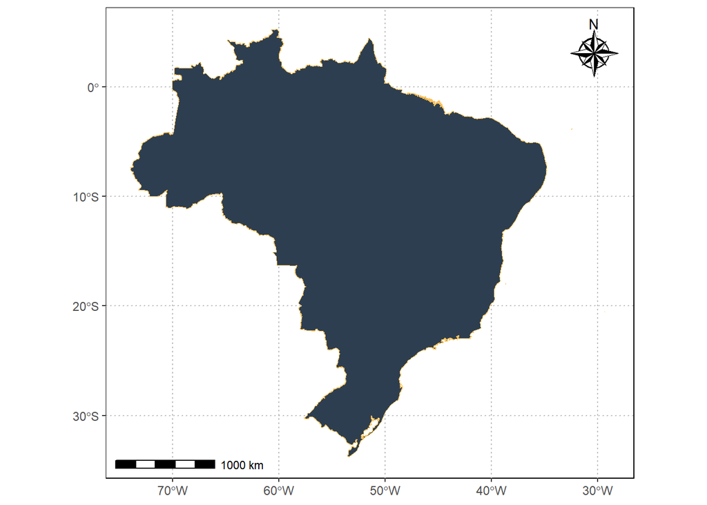

```r
br %>%
  ggplot() +
  geom_sf(fill="#2D3E50", color="#FEBF57",
          size=.15, show.legend = FALSE) +
  tema_mapa()
```

Plotando as regiões.

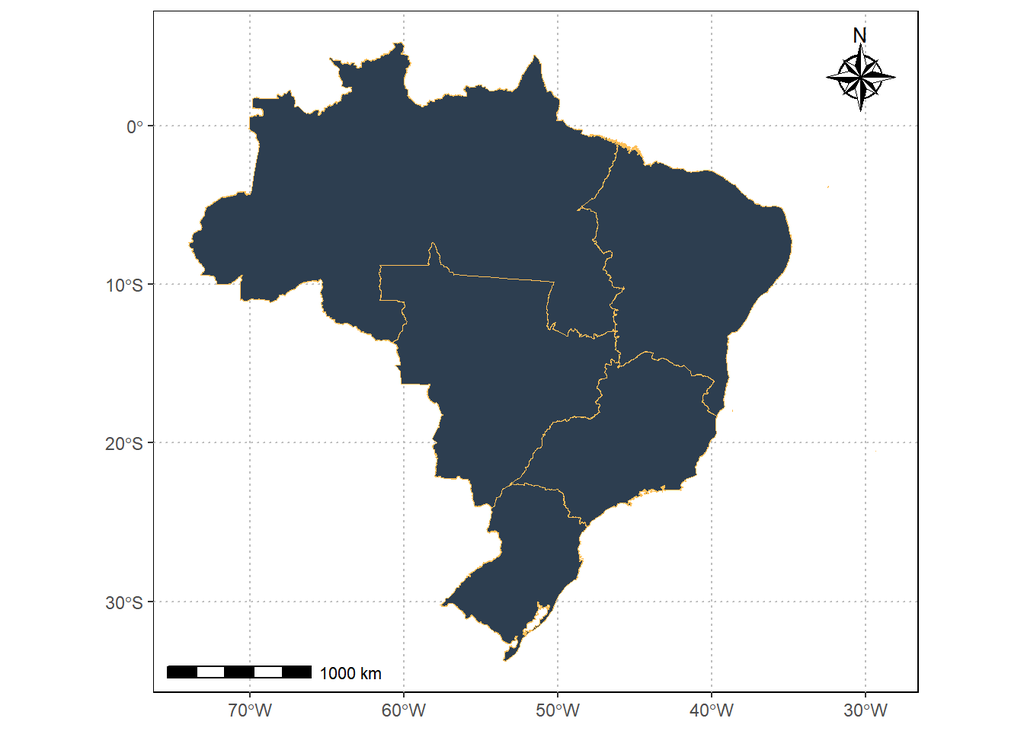

```r
regiao %>%
  ggplot() +
  geom_sf(fill="#2D3E50", color="#FEBF57",
          size=.15, show.legend = FALSE)+
  tema_mapa()
```

Plotando as delimitações do país com os estados.

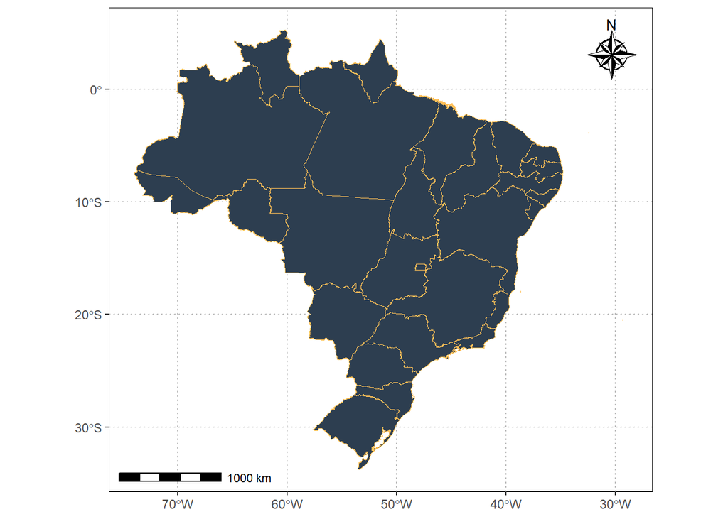

```r
estados %>%
  ggplot() +
  geom_sf(fill="#2D3E50", color="#FEBF57",
          size=.15, show.legend = FALSE)+
  tema_mapa()
```

Plotando as delimitações do país com os estados específicos.

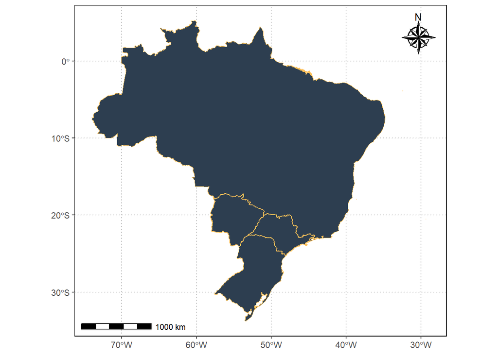

```r
# plotar os estados
br %>%
  ggplot() +
  geom_sf(fill="#2D3E50", color="#FEBF57",
          size=.15, show.legend = FALSE)+
  geom_sf(data=sp,fill="#2D3E50", color="#FEBF57")+
  geom_sf(data=ms,fill="#2D3E50", color="#FEBF57")+
  tema_mapa()
```

Todos os munícipios de um estados.

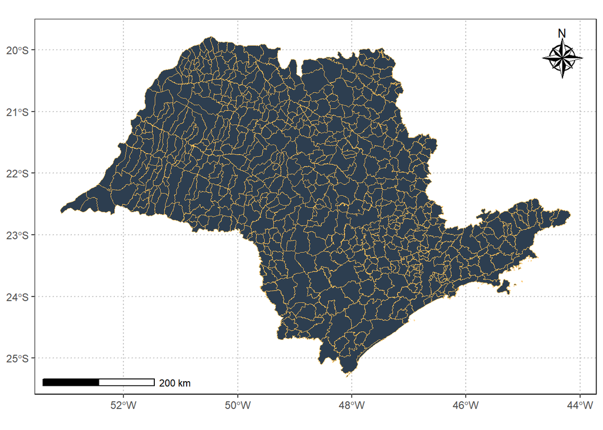

```r
# Fazer o plot
muni %>%
  ggplot() +
  geom_sf(fill="#2D3E50", color="#FEBF57",
          size=.15, show.legend = FALSE)+
  tema_mapa()
```

A partir do mapa base, vamos sobrepor os registros do objeto `oco_2`.

[figure not shown]

```r
br %>%
  ggplot() +
  geom_sf(fill="#2D3E50", color="#FEBF57",
          size=.15, show.legend = FALSE)+
  tema_mapa() +
  geom_point(data=oco_2 %>% filter(ano == 2014) ,
             aes(x=longitude,y=latitude),
             shape=3,
             col="red",
             alpha=0.2)
```

É necessário selecionar somente aqueles pontos dentro do polígono da área. Inicialmente devemos extrair o polígono de cada shape do pacote `geobr`.

```r
pol_sp <- as.matrix(sp$geom[[1]]) # pol estado de são paulo
pol_ms <- as.matrix(ms$geom[[1]]) # pol estado de ms
pol_br <- as.matrix(br$geom[[1]]) # pol do brasil
pol_br <- pol_br[pol_br[,1]<=-34,] # CORREÇÃO do polígono
pol_br <- pol_br[!((pol_br[,1]>=-38.8 & pol_br[,1]<=-38.6) &
                              (pol_br[,2]>= -19 & pol_br[,2]<= -16)),]
pol_norte <- as.matrix(regiao$geom[[1]]) # pol região norte
pol_sudeste <- as.matrix(regiao$geom[[3]]) # pol região sudeste
pol_sudeste <- pol_sudeste[pol_sudeste[,1]<=-34,] # CORREÇÃO do polígono
pol_sul <- as.matrix(regiao$geom[[4]]) # pol região sul
pol_centro_oeste <- as.matrix(regiao$geom[[5]]) # pol centro oeste
pol_nordeste <- as.matrix(regiao$geom[[2]]) # pol nordeste
pol_nordeste <- pol_nordeste[pol_nordeste[,1]<=-34,]# CORREÇÃO do polígono
pol_nordeste <- pol_nordeste[!((pol_nordeste[,1]>=-38.7 & pol_nordeste[,1]<=-38.6) &
                              pol_nordeste[,2]<= -15),]# CORREÇÃO do polígono
```

Selecionamos os pontos que estão dentro do polígono do estado de São Paulo e Mato Grosso do Sul, no nosso exemplo. Utilizaremos a função `point.in.polygon()` do pacote `sp`.

```r
oco_2 <- oco_2 %>%
  mutate(
    point_in_pol = as.logical(sp::point.in.polygon(point.x = longitude,
                                    point.y = latitude,
                                    pol.x = pol_sp[,1],
                                    pol.y = pol_sp[,2])
                              |
                              sp::point.in.polygon(point.x = longitude,
                                    point.y = latitude,
                                    pol.x = pol_ms[,1],
                                    pol.y = pol_ms[,2]))
  )
```

Vamos refazer o mapa anterior com os dados dentro do polígono.

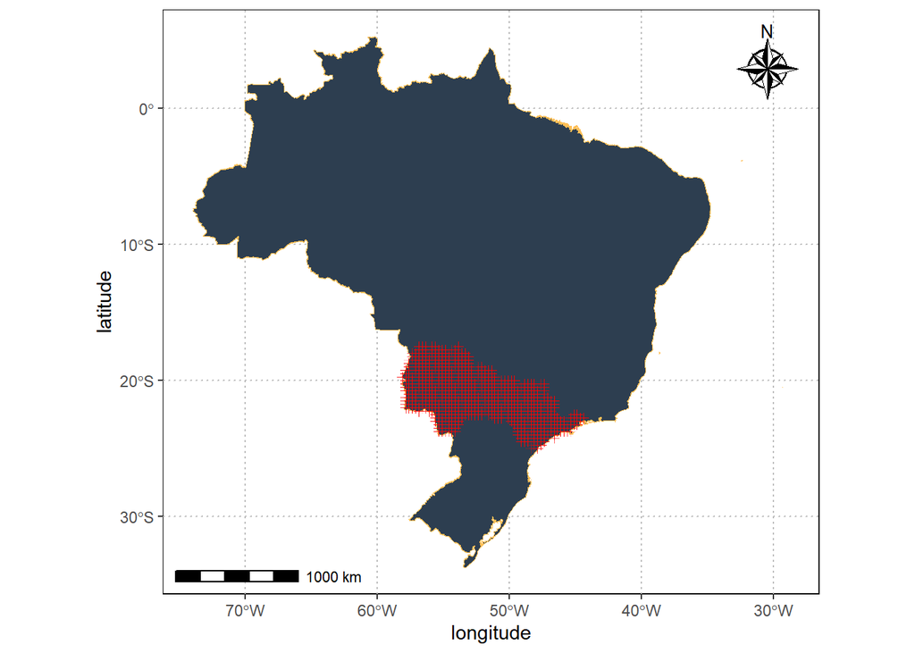

```r
br %>%
  ggplot() +
  geom_sf(fill="#2D3E50", color="#FEBF57",
          size=.15, show.legend = FALSE)+
  tema_mapa() +
  geom_point(data=oco_2 %>% filter(point_in_pol),
             aes(x=longitude,y=latitude),
             shape=3,
             col="red",
             alpha=0.2)
```

Selecionamos os pontos que estão dentro do Brasil.

```r
oco_2 <- oco_2 %>%
  mutate(
    point_in_pol = as.logical(sp::point.in.polygon(point.x = longitude,
                                    point.y = latitude,
                                    pol.x = pol_br[,1],
                                    pol.y = pol_br[,2])))
```

Vamos refazer o mapa anterior com os dados dentro do polígono.

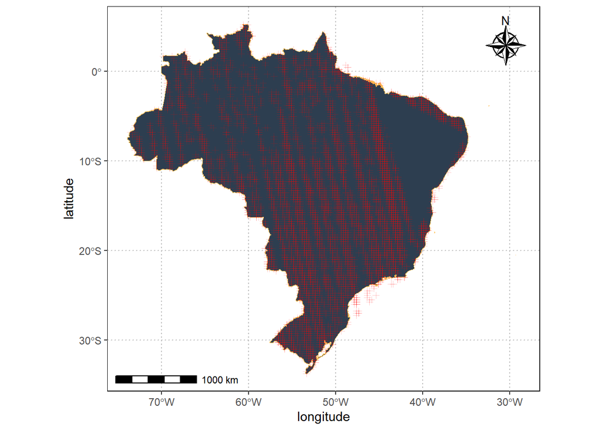

```r
br %>%
  ggplot() +
  geom_sf(fill="#2D3E50", color="#FEBF57",
          size=.15, show.legend = FALSE)+
  tema_mapa() +
  geom_point(data=oco_2 %>% filter(ano==2014, point_in_pol),
             aes(x=longitude,y=latitude),
             shape=3,
             col="red",
             alpha=0.2)
```

Observa-se um problema na região nordeste, pontos não alocados, então vamos adicionar a esse mapa os pontos dessa região.

```r
oco_2 <- oco_2 %>%
  mutate(
    point_in_pol = as.logical(sp::point.in.polygon(point.x = longitude,
                                    point.y = latitude,
                                    pol.x = pol_br[,1],
                                    pol.y = pol_br[,2])
                              |
                              sp::point.in.polygon(point.x = longitude,
                                    point.y = latitude,
                                    pol.x = pol_nordeste[,1],
                                    pol.y = pol_nordeste[,2]))
  )
```

Vamos refazer o mapa anterior com os dados dentro do polígono.

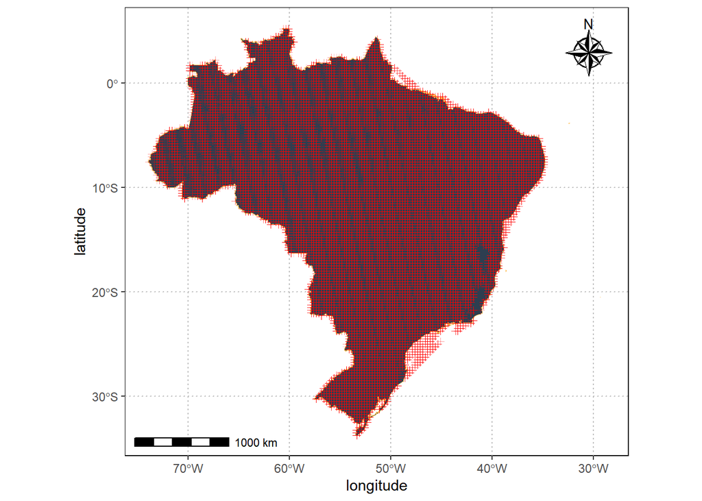

```r
br %>%
  ggplot() +
  geom_sf(fill="#2D3E50", color="#FEBF57",
          size=.15, show.legend = FALSE)+
  tema_mapa() +
  geom_point(data=oco_2 %>% filter(point_in_pol),
             aes(x=longitude,y=latitude),
             shape=3,
             col="red",
             alpha=0.2)
```

Vamos olhar os outliers.

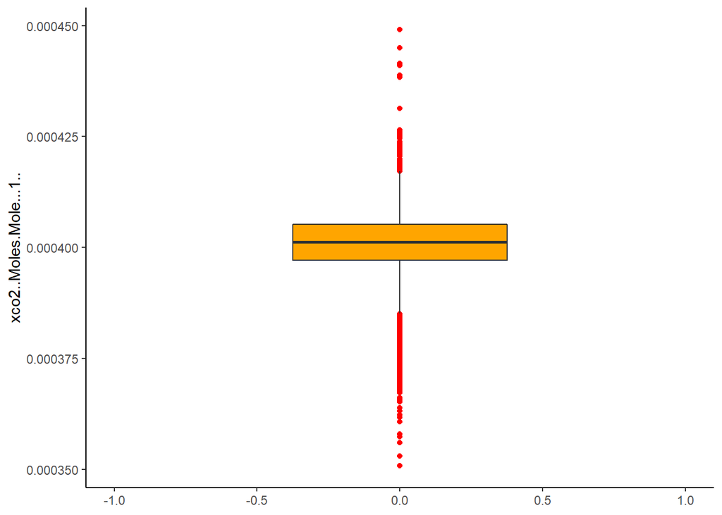

```r
oco_2 %>%
  filter(point_in_pol) %>%
  ggplot(aes(y=xco2..Moles.Mole...1..))+
  geom_boxplot(fill="orange",outlier.colour = "red")+
  coord_cartesian(xlim=c(-1,1))+
  theme_classic()
```

O padrão de `coef` é 1,5 e define o comprimento dos bigodes com base no coeficiente e na distância interquartil, com todos os pontos fora dos bigodes considerados outliers.